# Dataset Examples

# Package *AES*

Applied Econometrics with R

Functions, data sets, examples, demos, and vignettes for the book Christian Kleiber and Achim Zeileis (2008), Applied Econometrics with R, Springer-Verlag, New York.

```r
install.packages( "AER" )
library( AER )

vignette( "AER" )
```

## California Schools Data

The data used here are from all 420 K-6 and K-8 districts in California with data available for 1998 and 1999.

Test scores are on the Stanford 9 standardized test administered to 5th grade students. School characteristics (averaged across the district) include enrollment, number of teachers (measured as “full-time equivalents”, number of computers per classroom, and expenditures per student. Demographic variables for the students are averaged across the district. The demographic variables include the percentage of students in the public assistance program CalWorks (formerly AFDC), the percentage of students that qualify for a reduced price lunch, and the percentage of students that are English learners (that is, students for whom English is a second language).

**Data Dictionary**

- **district**: District code (character)
- **stratio**: Student-teacher ratio (calculated below)
- **score**: Average of two primary scores, math and reading
- **school**: School name (character)
- **county**: indicating county (factor)
- **grades**: indicating grade span of district (factor)
- **students**: Total enrollment
- **teachers**: Number of teachers
- **calworks**: Percent qualifying for CalWorks (income assistance)
- **lunch**: Percent qualifying for reduced-price lunch
- **computer**: Number of computers
- **expenditure**: Expenditure per student
- **income**: District average income (in USD 1,000)
- **english**: Percent of English learners
- **read**: Average reading score
- **math**: Average math score

### Specification

What happens to the significance of the student-teacher ratio variable once appropriate controls are added to the model?

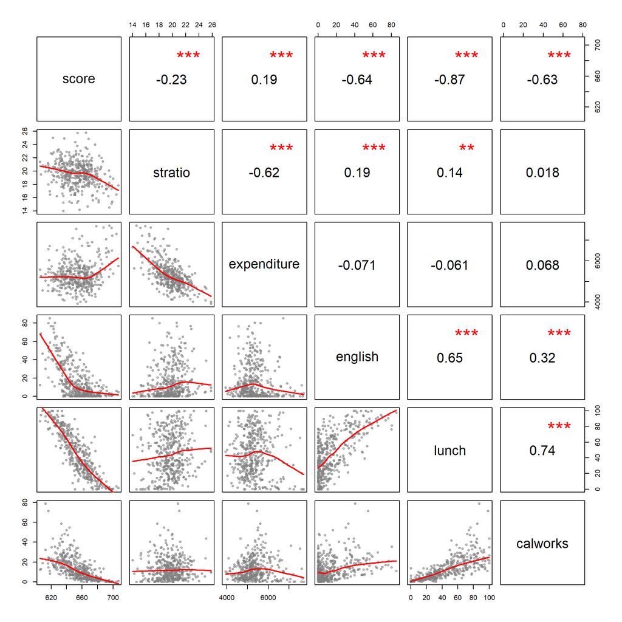

```r
data( "CASchools" )

## variable transformations
CASchools$stratio <- with(CASchools, students/teachers)
CASchools$score <- with(CASchools, (math + read)/2)


dat <- dplyr::select( CASchools, score, stratio, expenditure, english, lunch, calworks )

pairs( dat, lower.panel=panel.smooth, upper.panel=panel.cor)
```

```r
## Stock and Watson (2007)
## p. 152
fm1 <- lm( score ~ stratio, data = CASchools )
# coeftest(fm1, vcov = sandwich)

## p. 159
fm2 <- lm( score ~ I(stratio < 20), data = CASchools )

## p. 199
fm3 <- lm( score ~ stratio + english, data = CASchools )

## p. 224
fm4 <- lm( score ~ stratio + expenditure + english, data = CASchools )


stargazer( fm1, fm2, fm3, fm4, type="html",
           omit.stat = c("rsq", "f", "ser"),
           digits=2)
```

|  | *Dependent variable:* |  |  |  |
| --- | --- | --- | --- | --- |
|  | score |  |  |  |
|  | (1) | (2) | (3) | (4) |
| stratio | -2.28*** |  | -1.10*** | -0.29 |
|  | (0.48) |  | (0.38) | (0.48) |
| I(stratio < 20) |  | 7.17*** |  |  |
|  |  | (1.85) |  |  |
| expenditure |  |  |  | 0.004*** |
|  |  |  |  | (0.001) |
| english |  |  | -0.65*** | -0.66*** |
|  |  |  | (0.04) | (0.04) |
| Constant | 698.93*** | 650.08*** | 686.03*** | 649.58*** |
|  | (9.47) | (1.39) | (7.41) | (15.21) |
| Observations | 420 | 420 | 420 | 420 |
| Adjusted R<sup>2</sup> | 0.05 | 0.03 | 0.42 | 0.43 |
| *Note:* | p<0.1; p<0.05; p<0.01 |  |  |  |

### Additional Controls

Control for non-native speakers and income level of students.

```r
## Table 7.1, p. 242 (numbers refer to columns)
fmc3 <- lm( score ~ stratio + english + lunch, data = CASchools )
fmc4 <- lm( score ~ stratio + english + calworks, data = CASchools )
fmc5 <- lm( score ~ stratio + english + lunch + calworks, data = CASchools )
```

```r
stargazer( fmc3, fmc4, fmc5, type="html",
           omit.stat = c("rsq", "f", "ser"),
           digits=2 )
```

|  | *Dependent variable:* |  |  |
| --- | --- | --- | --- |
|  | score |  |  |
|  | (1) | (2) | (3) |
| stratio | -1.00*** | -1.31*** | -1.01*** |
|  | (0.24) | (0.31) | (0.24) |
| english | -0.12*** | -0.49*** | -0.13*** |
|  | (0.03) | (0.03) | (0.03) |
| lunch | -0.55*** |  | -0.53*** |
|  | (0.02) |  | (0.03) |
| calworks |  | -0.79*** | -0.05 |
|  |  | (0.05) | (0.06) |
| Constant | 700.15*** | 698.00*** | 700.39*** |
|  | (4.69) | (6.02) | (4.70) |
| Observations | 420 | 420 | 420 |
| Adjusted R<sup>2</sup> | 0.77 | 0.63 | 0.77 |
| *Note:* | p<0.1; p<0.05; p<0.01 |  |  |

## Teacher Ratings

```r
data("TeachingRatings")

TeachingRatings$response.rate <- TeachingRatings$students / TeachingRatings$allstudents

TeachingRatings %>% head() %>% pander()
```

Table continues below

| minority | age | gender | credits | beauty | eval | division | native |
| --- | --- | --- | --- | --- | --- | --- | --- |
| yes | 36 | female | more | 0.2899 | 4.3 | upper | yes |
| no | 59 | male | more | -0.7377 | 4.5 | upper | yes |
| no | 51 | male | more | -0.572 | 3.7 | upper | yes |
| no | 40 | female | more | -0.678 | 4.3 | upper | yes |
| no | 31 | female | more | 1.51 | 4.4 | upper | yes |
| no | 62 | male | more | 0.5886 | 4.2 | upper | yes |

| tenure | students | allstudents | prof | response.rate |
| --- | --- | --- | --- | --- |
| yes | 24 | 43 | 1 | 0.5581 |
| yes | 17 | 20 | 2 | 0.85 |
| yes | 55 | 55 | 3 | 1 |
| yes | 40 | 46 | 4 | 0.8696 |
| yes | 42 | 48 | 5 | 0.875 |
| yes | 182 | 282 | 6 | 0.6454 |

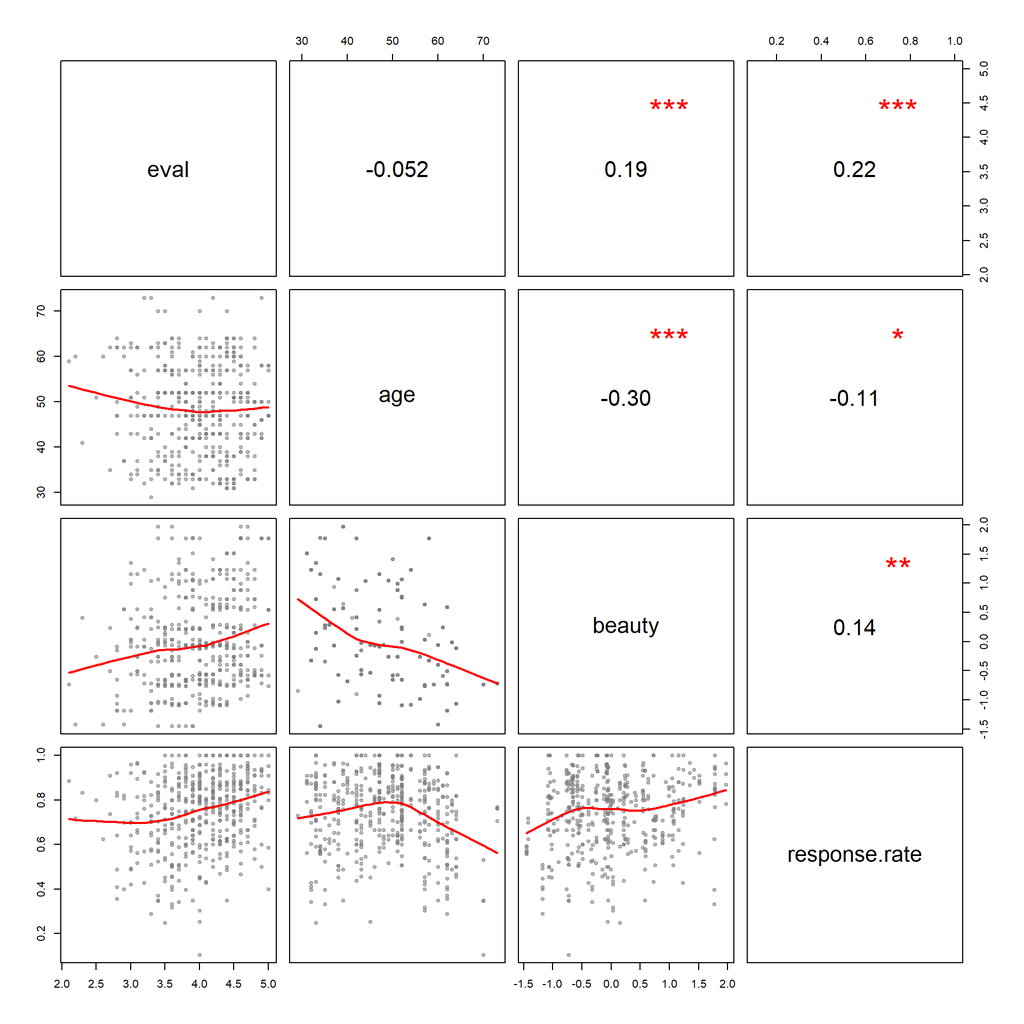

```r
dat <- dplyr::select( TeachingRatings, eval, age, beauty, response.rate )

pairs( dat, lower.panel=panel.smooth, upper.panel=panel.cor)
```

- Are beautiful people better teachers?
- What is the relationship between age and response rate?
- Are people content with a course more or less likely to submit evaluations?

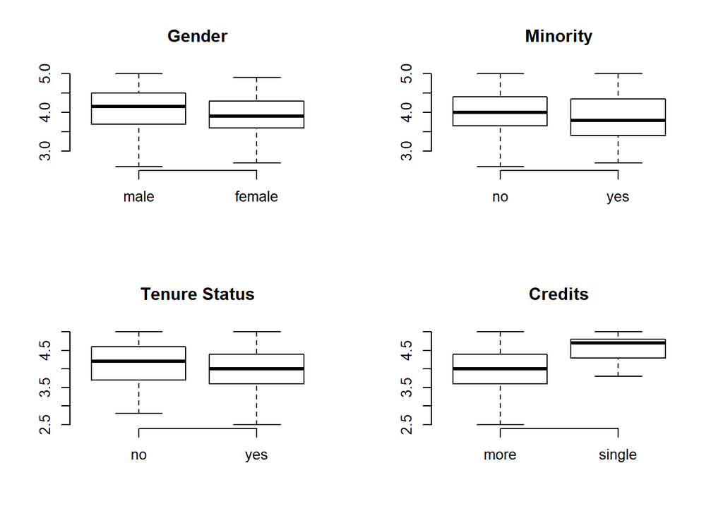

```r
par( mfrow=c(2,2) )
plot( TeachingRatings$gender, TeachingRatings$eval, frame.plot=F, outline=F, main="Gender" )
plot( TeachingRatings$minority, TeachingRatings$eval, frame.plot=F, outline=F, main="Minority" )
plot( TeachingRatings$tenure, TeachingRatings$eval, frame.plot=F, outline=F, main="Tenure Status" )
plot( TeachingRatings$credits, TeachingRatings$eval, frame.plot=F, outline=F, main="Credits" )
```

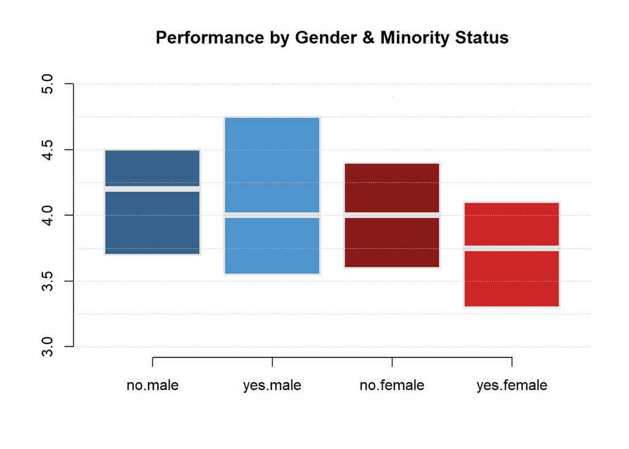

```r
group.structure <- formula( TeachingRatings$eval ~ TeachingRatings$minority * TeachingRatings$gender )

boxplot( group.structure, ylim=c(3,5),
         las=0, frame.plot=F, outline=F,
         main="Performance by Gender & Minority Status",
         col=c("steelblue4","steelblue3","firebrick4","firebrick3"),
         staplewex=0, whisklty=0, border="gray90", lwd=2 )

abline( h=seq(3,5,0.25), col="gray", lty=3, lwd=0.25 )
```